# Pest distribution modelling

Gabor Pozsgai

2025-03-17

[output not shown]

# Collecting data for each pest and natural enemy (NE) species

## Available pest data

Creating a list of all pests. Making a three data matrices of all UTM squares/hexagons/cells they are recorded from in the rows and 1) all predators, 2) all parasitoids, and 3) all NE species they are linked to in the columns with the number of records from one cell as data. Adding a vector with the summary values of all predators, parasitoids and all NEs, the number of records, number of squares recorded from to the list.

```
##            used  (Mb) gc trigger   (Mb) max used   (Mb)
## Ncells 12711755 678.9   19782582 1056.6 24728227 1320.7
## Vcells 40592740 309.7   81554531  622.3 81554531  622.3
```

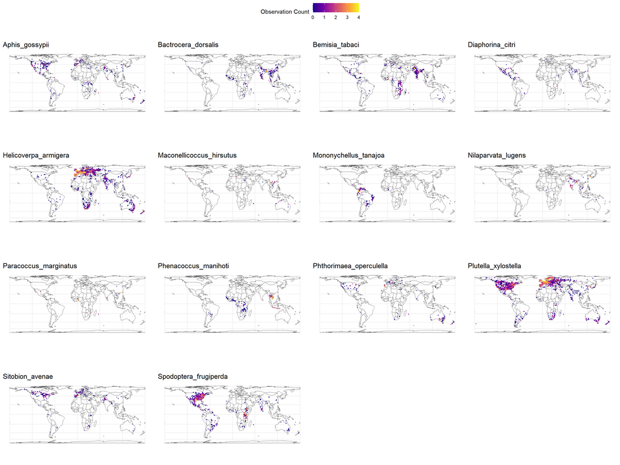

## Available NE data

Creating a list of all NEs. Making a data matrix of all UTM squares/hexagons/cells they are recorded from in the rows and all pest species they are linked to in the columns with the number of records from one cell as data. Adding a vector with the summary values of all controlled pests, number of records, number of squares recorded from to the list.

```
## Aphis_gossypiiBactrocera_dorsalisBemisia_tabaciDiaphorina_citriHelicoverpa_armigeraMaconellicoccus_hirsutusMononychellus_tanajoaNilaparvata_lugensParacoccus_marginatusPhenacoccus_manihotiPhthorimaea_operculellaPlutella_xylostellaSitobion_avenaeSpodoptera_frugiperda
```

```
## [1] 439
```

```
## Aphis_gossypiiBactrocera_dorsalisBemisia_tabaciDiaphorina_citriHelicoverpa_armigeraMaconellicoccus_hirsutusMononychellus_tanajoaNilaparvata_lugensParacoccus_marginatusPhenacoccus_manihotiPhthorimaea_operculellaPlutella_xylostellaSitobion_avenaeSpodoptera_frugiperda
```

```
## [1] 196
```

# Modelling current distributions

## Modelled distributions of pests

We model the current distribution of pests and we add a data frame of all UTM squares/hexagons/cells they are expected to occur to the list.

We also map the model of the current distribution of pests.

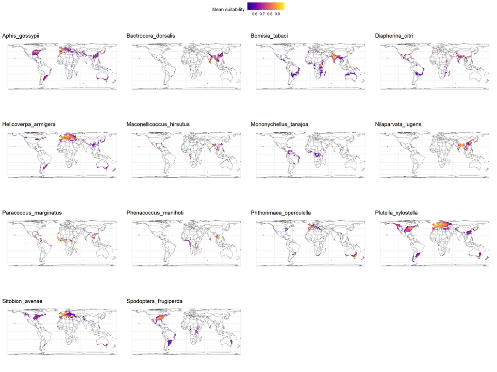

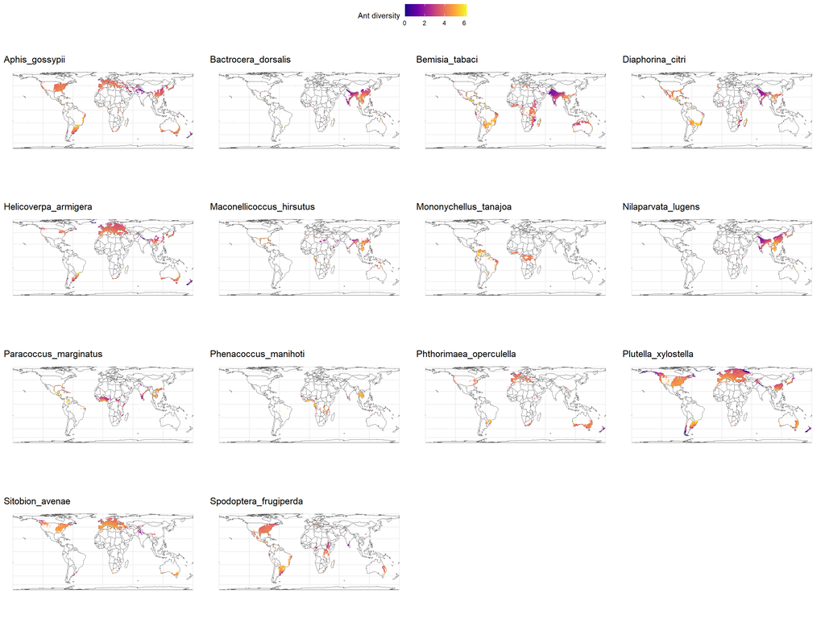

## Modelled distributions of natural enemies

We model the current distribution of NEs and we add a data frame of all UTM squares/hexagons/cells they are expected to occur to the list.

## Modelling distributions of NE genera

We collect the genera of NEs and model their current distribution. We add a data frame of all UTM squares/hexagons/cells they are expected to occur to the list.

# Modelling future distributions of pests

## Climate change scenario 1

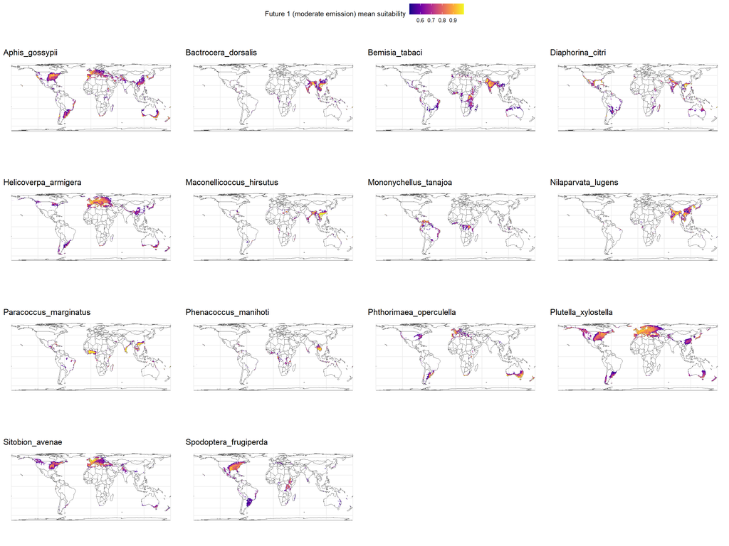

[figure not shown]

## Climate change scenario 2

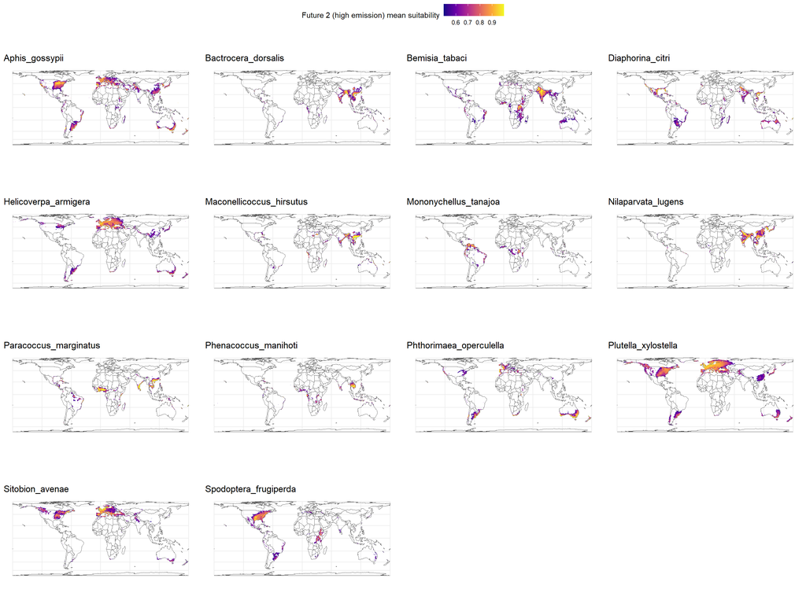

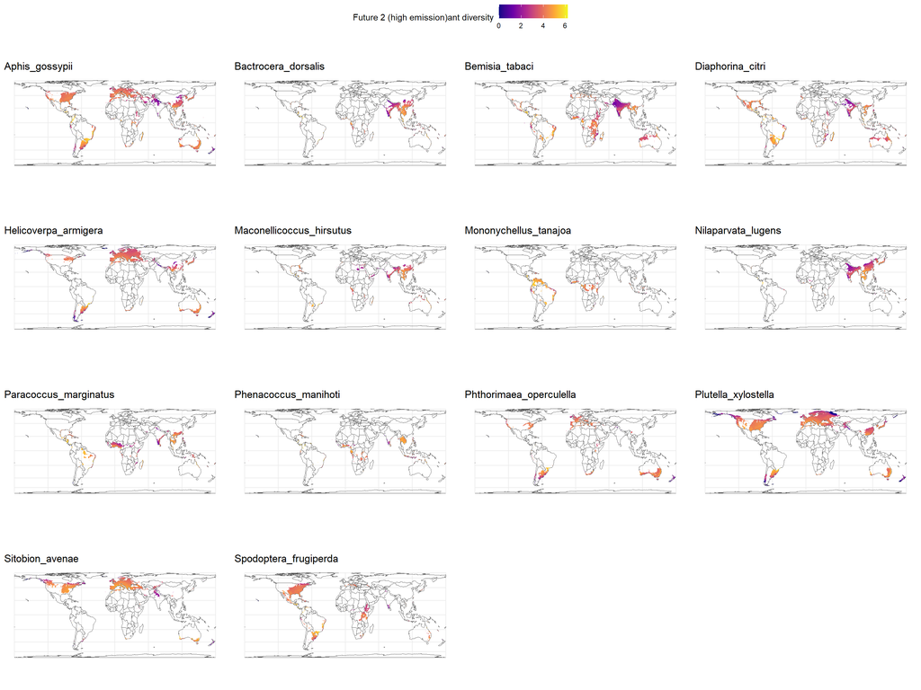

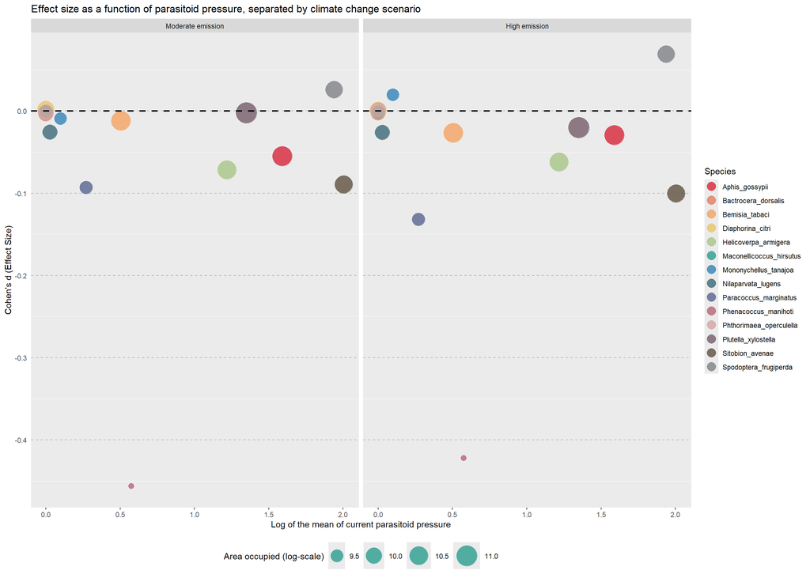

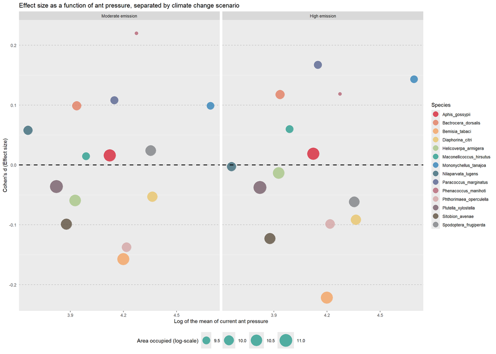

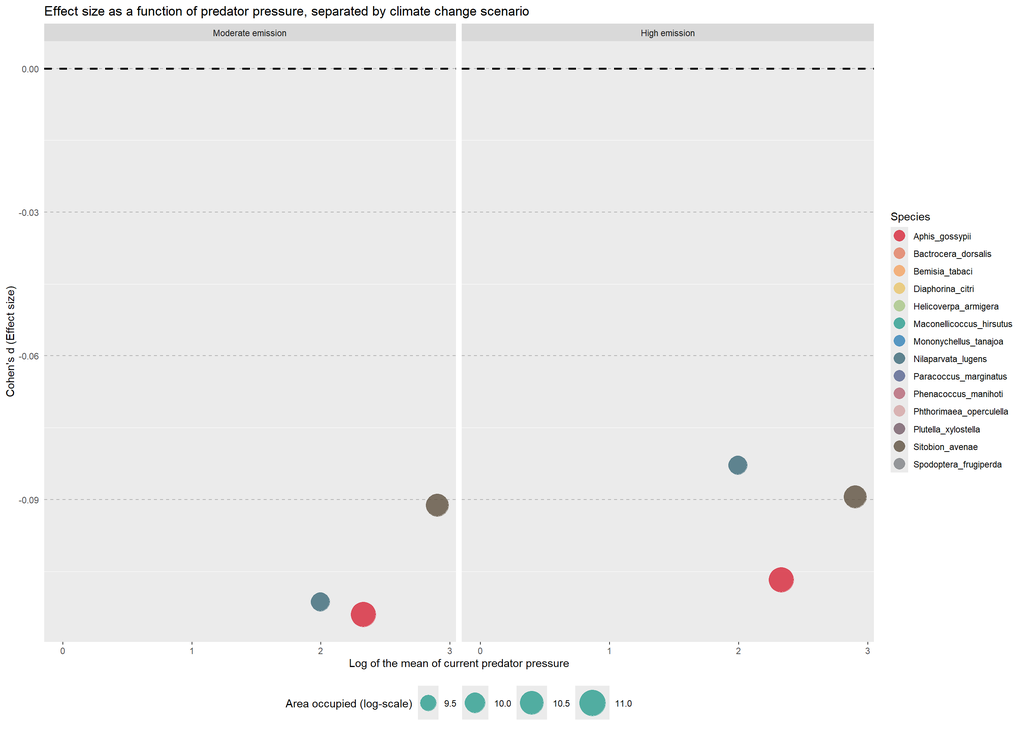

# Final outputs:

1. for each recorded square of pests: how many recorded NEs (separated as parasitoids, predators, and all)
2. for each modelled current distribution square of pests:
3. how many recorded NEs (separated as parasitoids, predators, and all)
4. how many modelled NEs (separated as parasitoids, predators, and all)
5. for each modelled future distribution (Scenario 1) square of pests:
6. how many recorded NEs (separated as parasitoids, predators, and all)
7. how many modelled NEs (separated as parasitoids, predators, and all)
8. how many modelled NE genera (separated as parasitoids, predators, and all)
9. how many modelled future (Scenario 1) NEs (separated as parasitoids, predators, and all)
10. for each modelled future distribution (Scenario 2) square of pests:
11. how many recorded NEs (separated as parasitoids, predators, and all)
12. how many modelled NEs (separated as parasitoids, predators, and all)
13. how many modelled NE genera (separated as parasitoids, predators, and all)
14. how many modelled future (Scenario 2) NEs (separated as parasitoids, predators, and all)